# Reshaping Data

Author

Mark Nepf (mnepf@uw.edu)

Published

October 1, 2026

## Introduction

When working with data, you will often encounter situations where the information you need is organized in a format that is not convenient for the task you want to perform. For example, you might have measurements stored across several columns when you need them in a single column, or you might have multiple rows for each observation when you would prefer each observation to occupy a single row.

Reshaping data is the process of reorganizing a dataframe without changing the underlying information it contains. Rather, reshaping changes how that information is distributed across rows and columns. Two common ways of organizing data are long format and wide format, and understanding the difference between these formats is an important part of working with data.

The goal of this vignette is to introduce the structure of long and wide data and demonstrate how to move between these formats using two `tidyverse` functions: `pivot_longer` and `pivot_wider`. We will begin by examining how the same information can be organized in long and wide formats and how the two structures differ.

We will then use `pivot_wider` to transform data from long to wide format and `pivot_longer` to perform the reverse operation. Along the way, we will examine the key arguments used by each function, including how to specify which columns should be transformed and how to name the resulting columns.

Finally, we will consider why the choice between long and wide format matters. Using simple examples, we will see how long format can make it easier to group, summarize, and visualize data, while wide format can make it easier to compare or combine measurements stored for the same observation.

By the end of this vignette, you should be able to recognize long and wide data, understand how the two formats differ, use `pivot_longer` and `pivot_wider` to reshape your own data, and choose an appropriate data format for a particular task.

### R Packages

You will need the following R packages. If you have already installed them, skip the `install.packages` lines.

```r
# install
install.packages("tidyverse")  # reshaping data
install.packages("gt")  # creating tables
```

```r
# load
library(tidyverse)
library(gt)
```

## Data Formats

Two of the most common ways to organize data are long format and wide format. The difference between the two has to do with how repeated measurements across the same observation are handled.

### Long

In long format, different measurements or categories are stored as values within a column, resulting in more rows. The resultant dataframe is one that is naturally longer, hence the name.

For example, suppose we have recorded the sales of three products during two months. We can create a simple dataframe using the `data.frame` function. We will call our products **A**, **B**, and **C** (*product* column), assume these products were sold in **January** and **February** (*month* column), and record the number of sales for each product-month combination (*sales* column).

```r
sales_long <- data.frame(

  # product being sold
  product = c("A", "A", "B", "B", "C", "C"),

  # month it was sold
  month = c("January", "February",
            "January", "February",
            "January", "February"),

  # quantity sold
  sales = c(100, 120, 80, 95, 150, 140)

  )

sales_long |> gt()
```

| product | month | sales |
| --- | --- | --- |
| A | January | 100 |
| A | February | 120 |
| B | January | 80 |
| B | February | 95 |
| C | January | 150 |
| C | February | 140 |

In the table above, each row represents a product-month combination. For example, the first row tells us that Product **A** had **100** sales in **January**, while the second row tells us that Product **A** had **120** sales in **February**.

Importantly, notice that each product (**A**, **B**, and **C**) appears twice - once for each month. This repetition is the defining feature of the long format structure: rather than creating a separate column for each month, the month is stored as a value in the *month* column.

### Wide

In wide format, different measurements or categories are stored in separate columns, resulting in more columns. The resultant dataframe is one that is naturally wider, hence the name.

Thinking again about our product sales example, we could just as well have recorded the number of sales for each product in separate columns that are named based on the month they were sold. We will still call our products **A**, **B**, and **C** (*product* column), but rather than storing the month as a value in its own column, we will create separate columns for *January* and *February* and record the number of sales for each product underneath the appropriate month.

```r
sales_wide <- data.frame(

  # product being sold
  product = c("A", "B", "C"),

  # quantity sold in January
  January = c(100, 80, 150),

  # quantity sold in February
  February = c(120, 95, 140)

  )

sales_wide |> gt()
```

| product | January | February |
| --- | --- | --- |
| A | 100 | 120 |
| B | 80 | 95 |
| C | 150 | 140 |

In the table above, each row represents a product. For example, the first row tells us that product **A** had **100** sales in *January* and **120** sales in *February*.

Importantly, notice that each product (**A**, **B**, and **C**) appears only once. This is the defining feature of the wide format structure: rather than storing the month as a value in a *month* column, each month is represented by its own column, with the corresponding sales values stored underneath it.

**NOTE**

Although the long and wide dataframes look quite different, they contain exactly the same information. The difference is simply how that information is organized. In the long format, the months are stored as values within a column and the products are repeated across rows. In the wide format, the months have become column names and each product occupies a single row.

## Reshaping

The `tidyverse` package provides two functions for moving between long and wide formats:

- `pivot_longer` transforms data from **wide to long format**
- `pivot_wider` transforms data from **long to wide format**

The names of these functions describe what they do. `pivot_longer` makes a dataframe longer by moving information from columns into rows, while `pivot_wider` makes a dataframe wider by moving information from rows into columns.

We can demonstrate both functions using the `sales_long` and `sales_wide` dataframes we created above.

### Long to Wide

Let’s begin with `pivot_wider`. As its name suggests, `pivot_wider` transforms a dataframe from long to wide format.

Recall our long format data:

```r
sales_long |> gt()
```

| product | month | sales |
| --- | --- | --- |
| A | January | 100 |
| A | February | 120 |
| B | January | 80 |
| B | February | 95 |
| C | January | 150 |
| C | February | 140 |

In this dataframe, the month is stored as a value in the *month* column, while the corresponding number of sales is stored in the *sales* column. Because each product has a separate row for each month, each product (**A**, **B**, and **C**) appears twice.

Suppose we instead want each product to appear only once, with separate columns for *January* and *February*. We can use `pivot_wider` to reorganize these data:

```r
sales_pivot_wide <- sales_long |>

  pivot_wider(

    # column containing values that will become new column names
    names_from = month,

    # column containing values that will populate the new columns
    values_from = sales

  )

sales_pivot_wide |> gt()
```

| product | January | February |
| --- | --- | --- |
| A | 100 | 120 |
| B | 80 | 95 |
| C | 150 | 140 |

The `pivot_wider` function uses two necessary arguments:

- `names_from` tells R which column contains the values that should become the **new column names**
- `values_from` tells R which column contains the **values that should populate those new columns**

In this example, *month* is the column that contains the values that we want to become column names (i.e., **January** and **February**), while *sales* contains the values that we want to appear underneath those new columns. Thus, the *month* column is supplied to the `names_from` argument and the *sales* column is supplied to the `values_from` argument.

**TIP**

When using `pivot_wider`, ask yourself these two questions:

1. Which column contains the values I want to turn into column names? This goes in `names_from`
2. Which column contains the values I want to put into those new columns? This goes in `values_from`

Importantly, notice that our original `sales_wide` dataframe, created manually, and the `sales_pivot_wide` dataframe, created using `pivot_wider`, are identical:

```r
sales_wide |> gt()
```

| product | January | February |
| --- | --- | --- |
| A | 100 | 120 |
| B | 80 | 95 |
| C | 150 | 140 |

```r
sales_pivot_wide |> gt()
```

| product | January | February |
| --- | --- | --- |
| A | 100 | 120 |
| B | 80 | 95 |
| C | 150 | 140 |

### Wide to Long

We can perform the reverse operation using `pivot_longer`. As its name suggests, `pivot_longer` transforms a dataframe from wide to long format.

Recall our wide format data:

```r
sales_wide |> gt()
```

| product | January | February |
| --- | --- | --- |
| A | 100 | 120 |
| B | 80 | 95 |
| C | 150 | 140 |

Here, the months are stored in separate columns (*January* and *February*). If we wanted to combine these columns back into a single *month* column, we would use `pivot_longer`:

```r
sales_pivot_long <- sales_wide |>

  pivot_longer(

    # columns containing values we want to combine
    cols = c(January, February),

    # name for new column containing the former column names
    names_to = "month",

    # name for new column containing the values
    values_to = "sales"

  )

sales_pivot_long |> gt()
```

| product | month | sales |
| --- | --- | --- |
| A | January | 100 |
| A | February | 120 |
| B | January | 80 |
| B | February | 95 |
| C | January | 150 |
| C | February | 140 |

The `pivot_longer` function uses three necessary arguments:

- `cols` tells R which columns we want to combine
  - Here, we want to combine the *January* and *February* columns
- `names_to` specifies the name of the new column that will contain the names of the columns being combined
  - We call this new column *month*
- `values_to` specifies the name of the new column that will contain the values stored in those columns
  - We call this new column *sales*

The *January* and *February* columns have been combined into two columns: *month* and *sales*. The former column names (*January* and *February*) become values in the *month* column, while the values previously stored in the *January* and *February* columns become values in the new *sales* column.

**TIP**

When using `pivot_longer`, ask yourself these three questions:

1. Which columns do I want to combine? These go in `cols`
2. What should I call the column containing their former names? This goes in `names_to`
3. What should I call the column containing their values? This goes in `values_to`

Importantly, notice that our original `sales_long` dataframe, created manually, and the `sales_pivot_long` dataframe, created using `pivot_longer`, are identical:

```r
sales_long |> gt()
```

| product | month | sales |
| --- | --- | --- |
| A | January | 100 |
| A | February | 120 |
| B | January | 80 |
| B | February | 95 |
| C | January | 150 |
| C | February | 140 |

```r
sales_pivot_long |> gt()
```

| product | month | sales |
| --- | --- | --- |
| A | January | 100 |
| A | February | 120 |
| B | January | 80 |
| B | February | 95 |
| C | January | 150 |
| C | February | 140 |

In sum, `pivot_wider` and `pivot_longer` perform opposite operations. `pivot_wider` takes values stored in rows and spreads them across columns; `pivot_longer` takes values stored across columns and combines them into rows. Critically, the data stored in each dataframe are identical. All that has changed is the organization of those data.

## Applications with Data Formats

These two formats are useful for different purposes. Neither long nor wide is universally better. Instead, the appropriate format depends on what you want to do with the data.

### Long

Long format is often useful when you want to perform the same operation across multiple measurements or categories. Because the measurements are stored as values within a column, functions can treat them consistently as a single variable.

For example, suppose we want to calculate the average sales across all product-month combinations in our dataset. In long format, all of the sales values are stored in a single *sales* column, making this operation straightforward.

```r
sales_long |> summarise(mean_sales = mean(sales)) |> gt()
```

| mean_sales |
| --- |
| 114.1667 |

We can also use `group_by` to calculate the average sales separately for each month:

```r
sales_long |>

  # group observations by month
  group_by(month) |>

  # summarize sales within those groups
  summarise(mean_sales = mean(sales)) |>

  gt()
```

| month | mean_sales |
| --- | --- |
| February | 118.3333 |
| January | 110.0000 |

Here, *month* is a variable containing two possible values (**January** and **February**), while *sales* is a single variable containing the corresponding measurements.

Long format is also particularly useful for visualization. For example, `ggplot` can use the values in the *month* and *sales* columns directly:

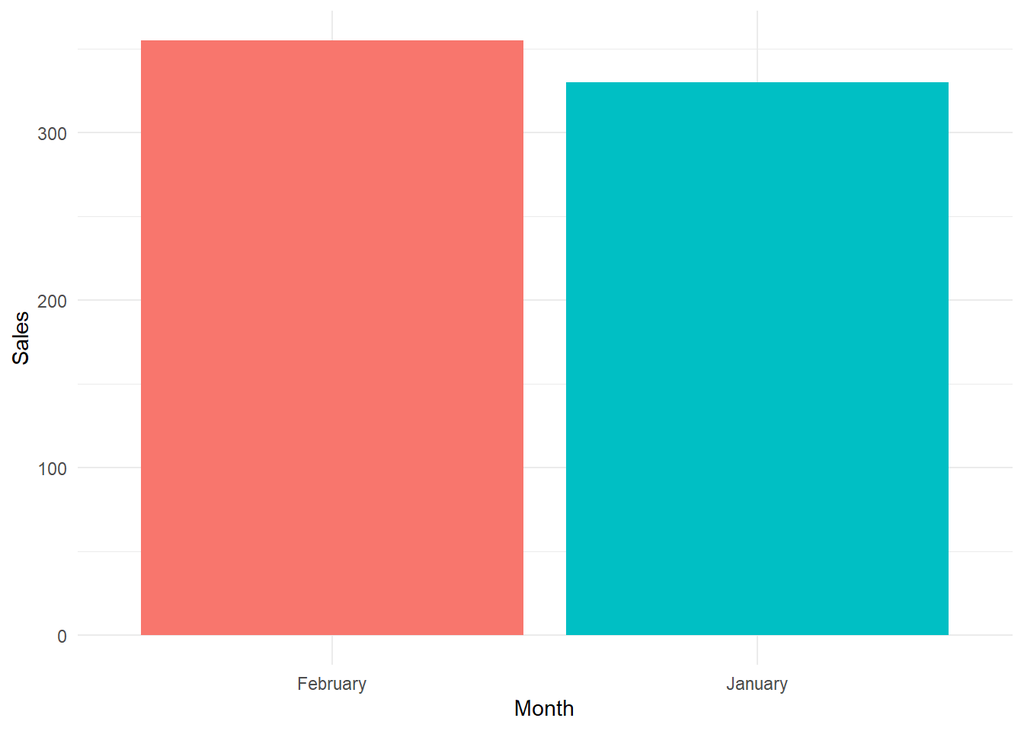

```r
sales_long |>

  ggplot(aes(x = month, y = sales, fill = month)) +  # `fill = month` colors the bars

  geom_col() +

  labs(x = "Month",
       y = "Sales") +

  theme_minimal() +

  # remove legend for cleaner look
  theme(legend.position = "none")
```

**TIP**

Long format is often useful when your data contain many repeated measurements and you want to group, summarize, filter, or visualize those measurements in a consistent way.

### Wide

Wide format is preferred when you want to compare related measurements side by side. Because each measurement has its own column, it can be easier to inspect the values for a particular observation.

For example, suppose we want to compare each product’s *January* and *February* sales. In wide format, both measurements are already available in the same row, so no additional operations are required:

```r
sales_wide |> gt()
```

| product | January | February |
| --- | --- | --- |
| A | 100 | 120 |
| B | 80 | 95 |
| C | 150 | 140 |

This also makes it straightforward to calculate the change in sales between the two months. Because *January* and *February* are separate columns, we can directly subtract one from the other:

```r
sales_wide |>

  # calculate change
  mutate(change = February - January) |>

  gt()
```

| product | January | February | change |
| --- | --- | --- | --- |
| A | 100 | 120 | 20 |
| B | 80 | 95 | 15 |
| C | 150 | 140 | -10 |

We could also calculate the percentage change:

```r
sales_wide |>

  # calculate percent change
  mutate(percent_change = (February - January) / January) |>

  gt() |>

  # format percent column for cleaner look
  fmt_percent(columns = percent_change,
              decimals = 1)
```

| product | January | February | percent_change |
| --- | --- | --- | --- |
| A | 100 | 120 | 20.0% |
| B | 80 | 95 | 18.8% |
| C | 150 | 140 | −6.7% |

Thus, wide format makes sense when the columns represent different measurements that you want to compare or combine within the same observation.

### Choosing a Format

The choice between long and wide format ultimately depends on the task you want to perform.

| Question | Format |
| --- | --- |
| What were the average sales for each month? | Long |
| How do sales vary across months? | Long |
| How can I plot sales by month? | Long |
| What is the change in product sales from January to February? | Wide |
| What is the percentage change for each product? | Wide |
| How many sales did each product have in each month? | Either |

**NOTE**

Keep in mind that you do not need to permanently choose one format for your data. You can reshape your dataframe whenever the structure of the data is no longer convenient for the task you want to perform.